# assessing stability of noise models

# 1 intro

Analysis to help guide use of noise models in pattern analysis.

Questions this analysis might help inform:

1. Is noise structure stable across runs within a task? across tasks?
   - For a given run (or task), can noise estimates from different runs (or tasks) be used to normalize patterns?
     - Does filtering higher-motion frames boost stability?
   - Are there ‘bad’ tasks or glms whose noise models should be scrutinized further?
2. What aspects of noise structure are stable across runs/tasks?
   - diagonal (variance), offidagonal (covariance)? — Should residual timeseries variance be used to downweight individual vertices?
   - magnitude (scale), direction (pattern)? — should covariance matrices be converted into correlation matrices?
3. What is the impact on cross-task stability of concatenating timeseries across runs versus estimating runwise then aggregating over runs?
   - how should noise models be estimated?

Stability statistics:

- stability can be assessed in mean (location), variance (scale/magnitude), angle (pattern ‘shape’)
- cor: linear correlation, sensitive to pattern shape
- cossim: cosine similarity, sensitive to pattern shape and location
- rmse: root mean squared error (a distance measure), sensitive to shape, location, and scale

subjs with complete data:

```
##  [1] 102008      107321      115825      123117      130114      130518
##  [7] 132017      141422      150423      158136      161832      165032
## [13] 173738      176845      178950      182436      203418      204319
## [19] 233326      300618      346945      393550      448347      580650
## [25] 594156      601127      672756      765864      849971      877168
## [31] DMCC0472647 DMCC1328342 DMCC1624043 DMCC3963378 DMCC4854984 DMCC5065053
## [37] DMCC5195268 DMCC5244053 DMCC5775387 DMCC6418065 DMCC6627478 DMCC6671683
## [43] DMCC6705371 DMCC7297690 DMCC7921988 DMCC8050964 DMCC8078683 DMCC8214059
## [49] DMCC9478705 DMCC9850294 DMCC9953810
## 55 Levels: 102008 107321 115825 123117 130114 130518 132017 141422 ... DMCC9953810
```

# 2 cross-run stability

Within-task comparisons.

## 2.1 mean across tasks

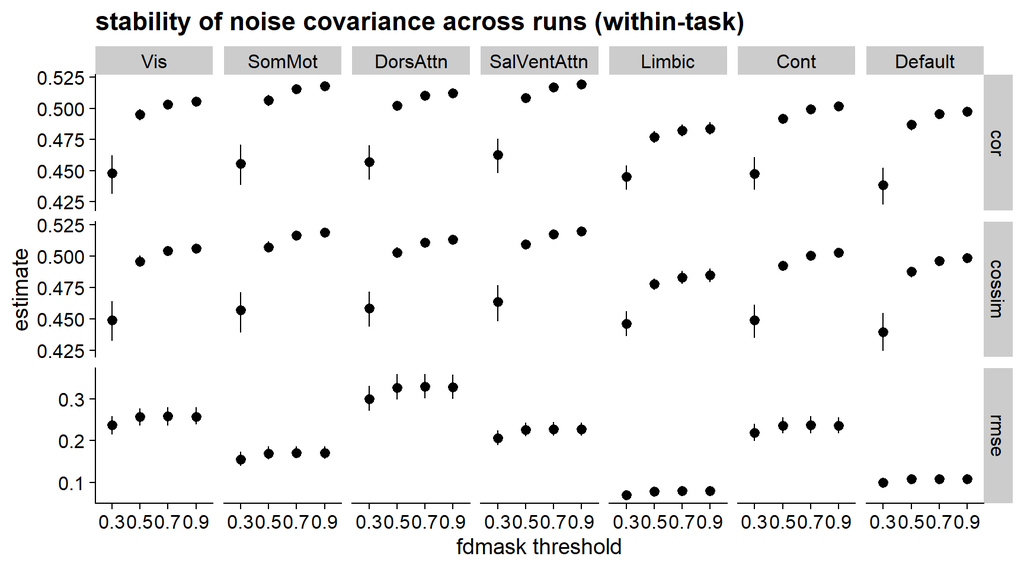

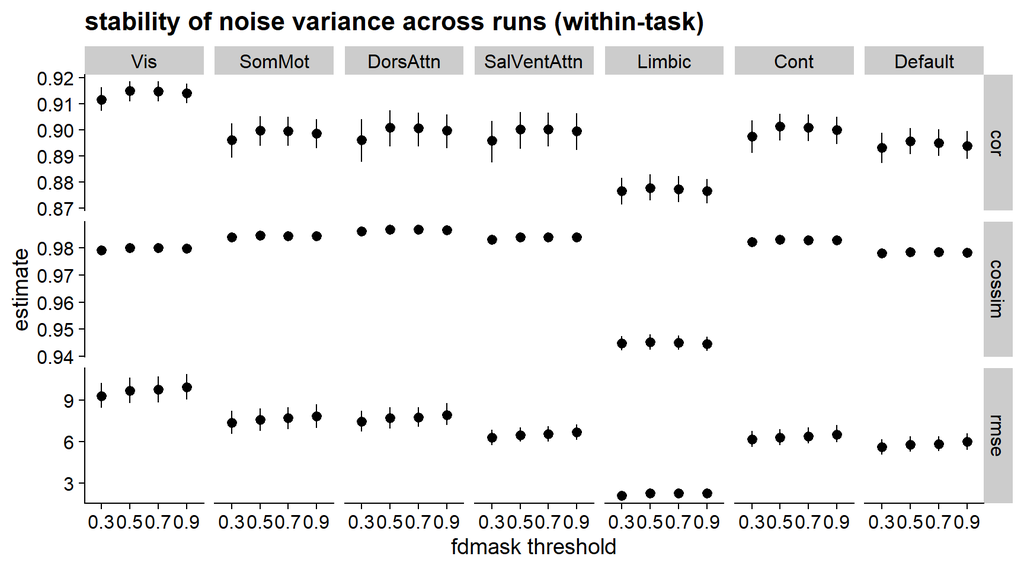

Stability of covariance strongly depends on amount of data (number of frames), above and beyond amount of motion in frames. Similar story told with variances, but much less strongly.

## 2.2 per task

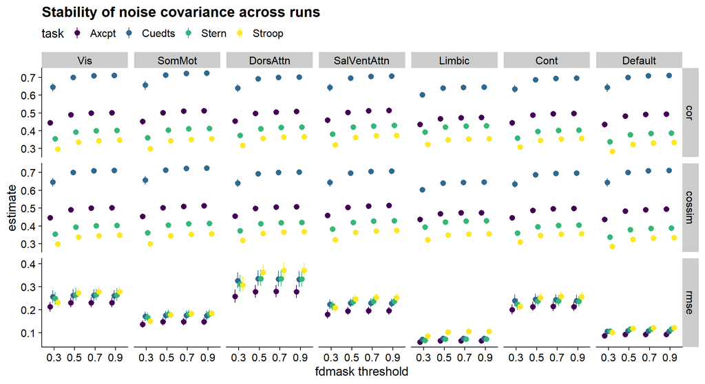

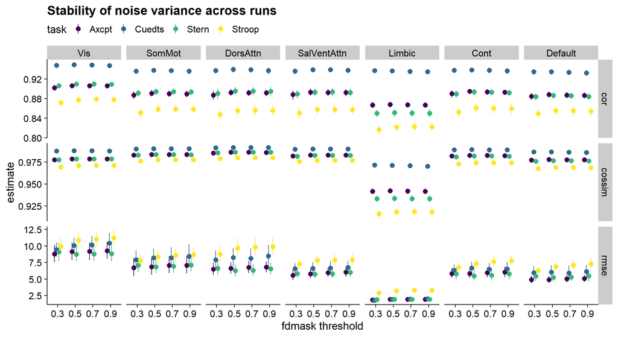

Large differences in stability of covariance across tasks. Cuedts > Axcpt > Stern > Stroop. This also matches the rank order of the number of TRs per task (in alphabetical order): 1220, 1300, 1200, 1080

# 3 cross-task stability

## 3.1 mean across tasks

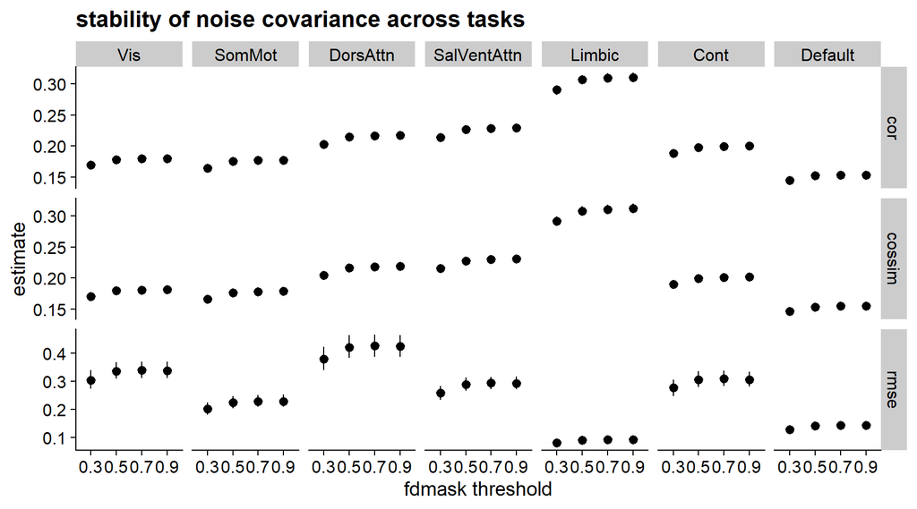

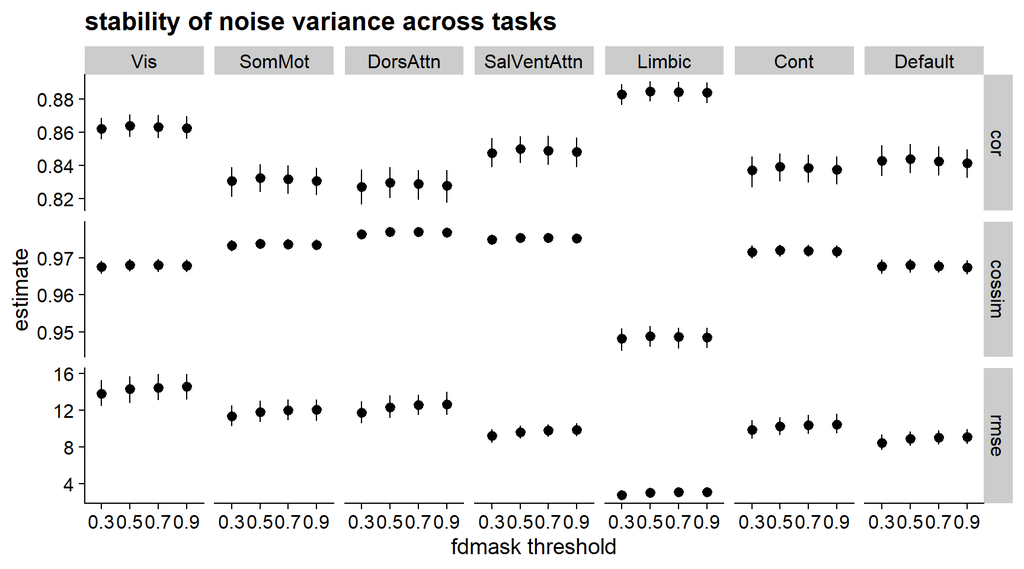

Similar story as cross-run within-task. More frames improves cross-task stability of noise covariance, above and beyond amount of motion. Less so with variances (variances already relatively stable).

## 3.2 per run

Within run 1 (run1~run1), within run 2 (run2~run2), between run (run1~run2). All comparisons between task.

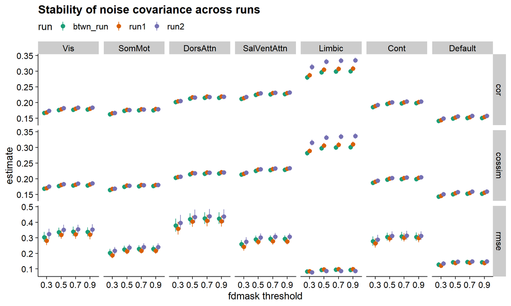

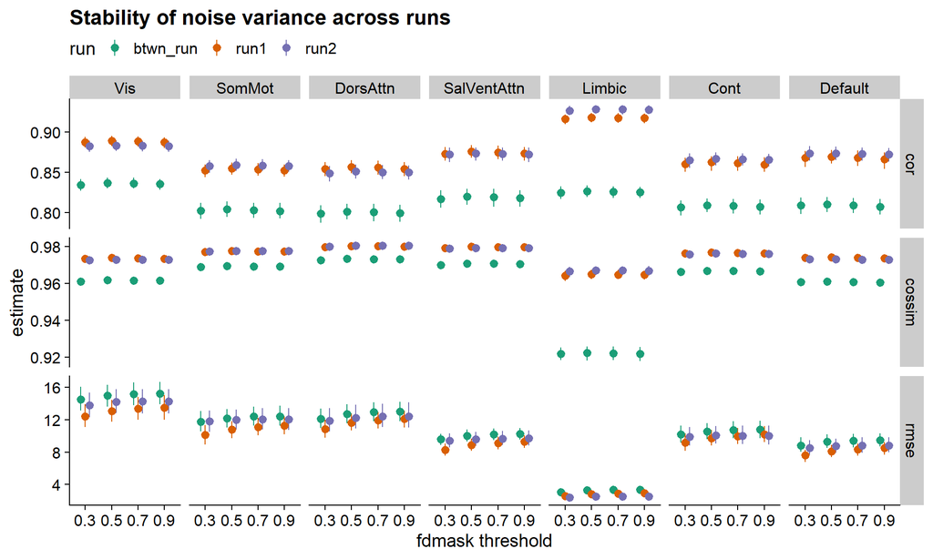

Run (1_AP, 2_PA) has weak impact on covariances (between run less stable), but strong impact on variances.

## 3.3 concatenated

With noise models from runs concatenated (along the time-dimension) prior to estimation.

```
##  [1] 102008      107321      115825      123117      130114      130518
##  [7] 132017      141422      150423      158136      161832      165032
## [13] 173738      176845      178950      182436      203418      204319
## [19] 233326      300618      346945      393550      432332      448347
## [25] 580650      594156      601127      672756      765864      849971
## [31] 877168      DMCC0472647 DMCC1328342 DMCC1624043 DMCC3963378 DMCC4854984
## [37] DMCC5065053 DMCC5195268 DMCC5244053 DMCC5775387 DMCC6418065 DMCC6627478
## [43] DMCC6671683 DMCC6705371 DMCC7297690 DMCC7921988 DMCC8050964 DMCC8078683
## [49] DMCC8214059 DMCC9478705 DMCC9850294 DMCC9953810
## 55 Levels: 102008 107321 115825 123117 130114 130518 132017 141422 ... DMCC9953810
```

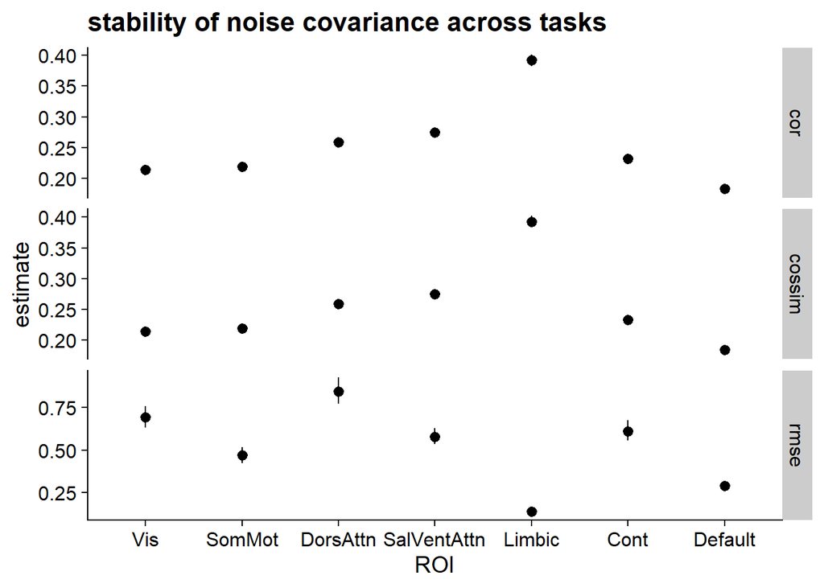

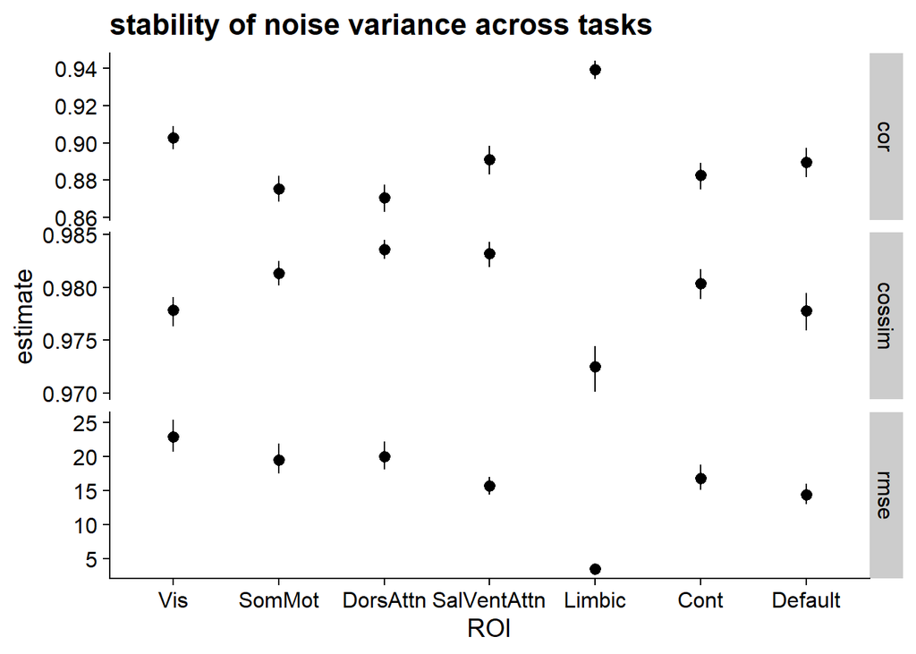

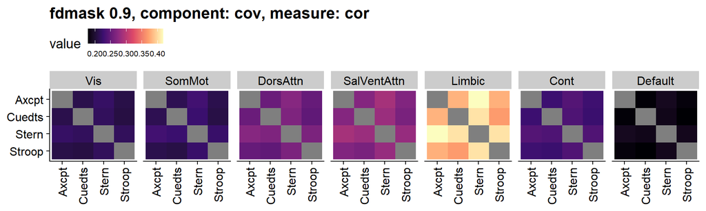

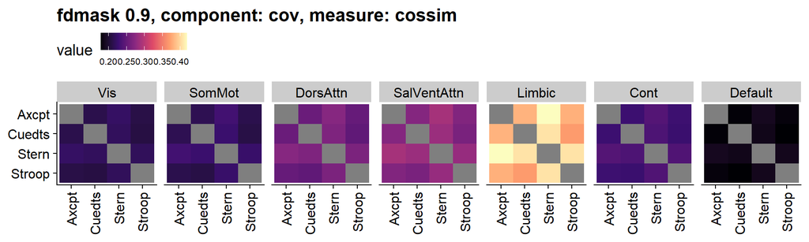

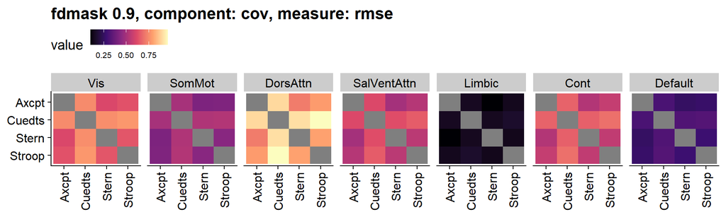

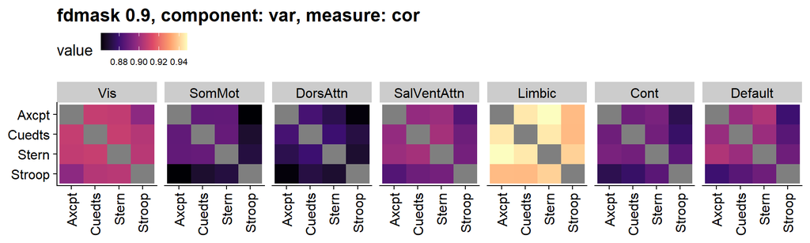

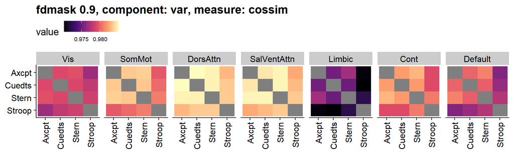

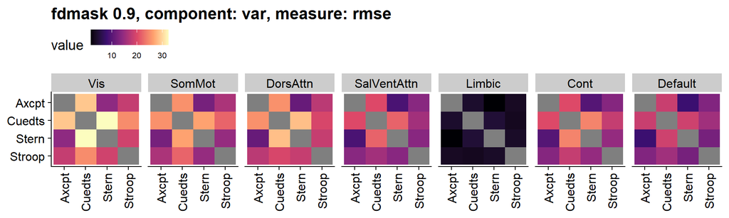

# 4 matrices

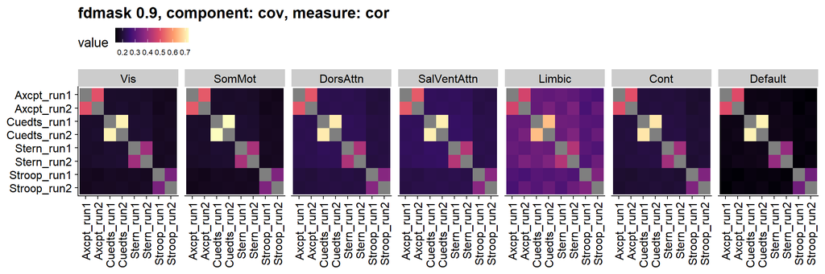

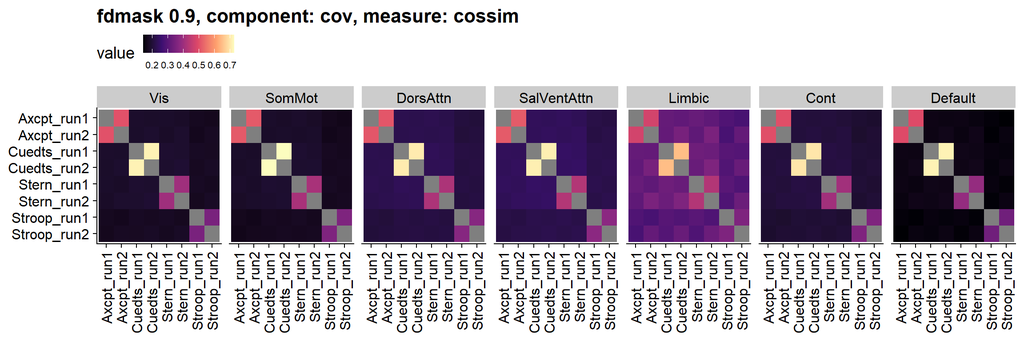

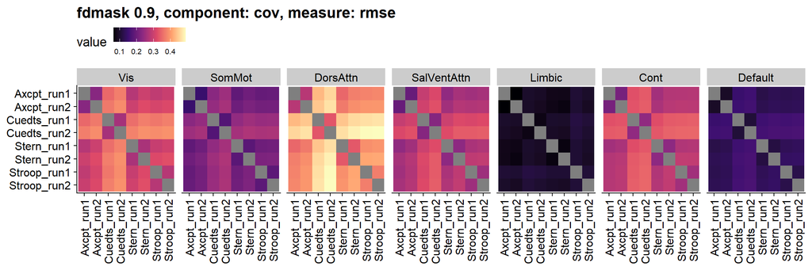

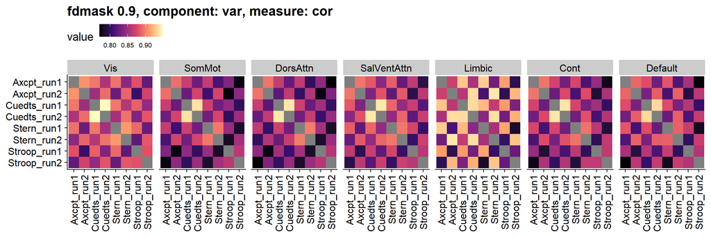

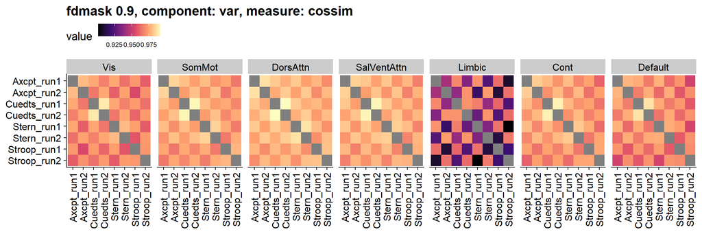

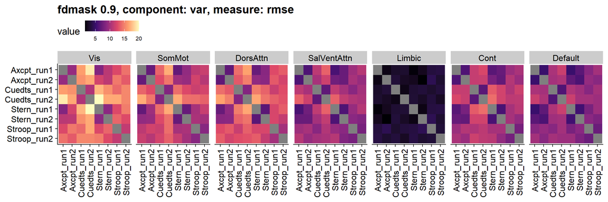